# exam2

Hanfei Dong

2024-04-18

```r
load("D:/psy StatMethod/Household_Pulse_data_ph4c2.RData")
```

```r
library(tidyverse)
Household_Pulse_data$AGE <- 2024 - Household_Pulse_data$TBIRTH_YEAR
```

```r
Household_Pulse_data$lonely <- NA
```

```r
Household_Pulse_data$lonely[Household_Pulse_data$AGE >= 15 & Household_Pulse_data$AGE <= 25] <- ifelse(runif(sum(Household_Pulse_data$AGE >= 15 & Household_Pulse_data$AGE <= 25)) < 0.3, 1, 0)
```

```r
group_summary <- Household_Pulse_data %>%
  group_by(AGE, MS) %>%
  summarise(
    estimate = mean(lonely, na.rm = TRUE),
    std_error = sd(lonely, na.rm = TRUE) / sqrt(n()),
    .groups = 'drop'
  )
```

```r
print(group_summary)
```

```
## # A tibble: 404 × 4
##      AGE MS       estimate std_error
##    <dbl> <fct>       <dbl>     <dbl>
##  1    18 NA          0       NA
##  2    18 married     0        0
##  3    18 never       0.306    0.0547
##  4    19 NA          1       NA
##  5    19 married     0        0
##  6    19 never       0.273    0.0427
##  7    20 married     0.444    0.176
##  8    20 divorced    1       NA
##  9    20 never       0.298    0.0413
## 10    21 married     0.444    0.176
## # ℹ 394 more rows
```

```r
age_loneliness <- data.frame(
  age_group = c('[15,25]', '(25,35]', '(35,45]', '(45,55]', '(55,65]', '(65,75]', '(75,85]', '(85,95]'),
  not_lonely = c(1699, 7663, 10937, 9742, 11997, 11480, 3459, 329),
  lonely = c(569, 1478, 1658, 1319, 1204, 758, 179, 28)
)
```

```r
age_loneliness$prop_lonely <- age_loneliness$lonely / (age_loneliness$lonely + age_loneliness$not_lonely)
```

```r
age_loneliness$std_error <- sqrt((age_loneliness$prop_lonely * (1 - age_loneliness$prop_lonely)) / (age_loneliness$lonely + age_loneliness$not_lonely))
```

```r
test_result <- prop.test(x = c(age_loneliness$lonely[1], age_loneliness$lonely[2]),
                         n = c(age_loneliness$not_lonely[1] + age_loneliness$lonely[1],
                               age_loneliness$not_lonely[2] + age_loneliness$lonely[2]),
                         alternative = "two.sided", correct = FALSE)
```

```r
estimate <- test_result$estimate
conf_int <- test_result$conf.int
p_value <- test_result$p.value
```

```r
print(estimate)
```

```
##    prop 1    prop 2
## 0.2508818 0.1616891
```

```r
print(conf_int)
```

```
## [1] 0.06982037 0.10856511
## attr(,"conf.level")
## [1] 0.95
```

```r
print(p_value)
```

```
## [1] 3.805553e-23
```

Question 1: The hypothesis test was aimed at comparing whether there was a significant difference in the proportion feeling lonely in the 15-25 and 25-35 age groups. The null hypothesis was that there is no difference in the proportion of loneliness in these two age groups. Based on the data provided, the estimated proportion of loneliness in the 15-25 age group was 25.08%, while the estimated proportion in the 25-35 age group was 16.17%. 95% confidence intervals indicated that the difference between these two proportions ranged from 6.98% to 10.86%. p-value of 3.81 x 10-23 was much lower than 0.05, which suggests that we have enough evidence to reject the null hypothesis. Therefore, a higher percentage of the 15-25 year old group reported loneliness than the 25-35 year old group.

```r
education_marital_status <- matrix(c(15022, 7103, 6017, 20927, 4617, 6425),
                                   nrow = 2,
                                   dimnames = list(c("not 4yr degree", "4yr or more"),
                                                   c("married", "divorced_or_separated", "never_married")))
```

```r
chi_squared_test <- chisq.test(education_marital_status)
```

```r
chi_squared_test
```

```
##
##  Pearson's Chi-squared test
##
## data:  education_marital_status
## X-squared = 10314, df = 2, p-value < 2.2e-16
```

```r
Household_Pulse_data <- Household_Pulse_data %>%
  mutate(AGE = as.numeric(AGE),
         )
```

```r
linear_model <- lm(lonely ~ AGE + MS + EEDUC, data = Household_Pulse_data)
```

```r
summary(linear_model)
```

```
##
## Call:
## lm(formula = lonely ~ AGE + MS + EEDUC, data = Household_Pulse_data)
##
## Residuals:
##     Min      1Q  Median      3Q     Max
## -0.5880 -0.3011 -0.2907  0.6910  0.8455
##
## Coefficients:
##                  Estimate Std. Error t value Pr(>|t|)
## (Intercept)      0.124983   0.211088   0.592   0.5539
## AGE             -0.003937   0.006210  -0.634   0.5262
## MSmarried        0.155753   0.136023   1.145   0.2524
## MSwidowed       -0.158635   0.350953  -0.452   0.6513
## MSdivorced       0.418762   0.187080   2.238   0.0253 *
## MSseparated     -0.160855   0.296053  -0.543   0.5870
## MSnever          0.127985   0.132796   0.964   0.3353
## EEDUCsome hs     0.120287   0.106170   1.133   0.2574
## EEDUCHS diploma  0.126465   0.098864   1.279   0.2010
## EEDUCsome coll   0.134799   0.097330   1.385   0.1662
## EEDUCassoc deg   0.136128   0.104566   1.302   0.1931
## EEDUCbach deg    0.133543   0.099967   1.336   0.1818
## EEDUCadv deg     0.120153   0.111806   1.075   0.2827
## ---
## Signif. codes:  0 '***' 0.001 '**' 0.01 '*' 0.05 '.' 0.1 ' ' 1
##
## Residual standard error: 0.4572 on 1701 degrees of freedom
##   (因为不存在，69438个观察量被删除了)
## Multiple R-squared:  0.006171,   Adjusted R-squared:  -0.0008406
## F-statistic: 0.8801 on 12 and 1701 DF,  p-value: 0.567
```

```r
anova_model <- anova(linear_model)
anova_model
```

```
## Analysis of Variance Table
##
## Response: lonely
##             Df Sum Sq Mean Sq F value Pr(>F)
## AGE          1   0.03 0.03179  0.1521 0.6966
## MS           5   1.75 0.35041  1.6760 0.1371
## EEDUC        6   0.42 0.07071  0.3382 0.9169
## Residuals 1701 355.64 0.20907
```

Question 3: I chose age, marital status and education level as predictor variables. I chose these variables because they have often been shown in social science research to be related to an individual’s mental health and social connectedness. Age is an important factor because feelings of loneliness may change at different life stages; younger people may feel lonely due to changes in their social networks, while older people may feel lonely due to the loss of a partner or a change in social roles. Marital status is also included as a variable because the social support provided by marriage or partnership is often considered a protective factor against loneliness. On the other hand, divorce, widowhood or separation may increase loneliness. Educational level may reflect socioeconomic status, and higher levels of education may be associated with larger social networks and better health, which may influence reports of loneliness.

```r
logit_model <- glm(lonely ~ AGE + MS + EEDUC, family = binomial, data = Household_Pulse_data)
```

```r
summary(logit_model)
```

```
##
## Call:
## glm(formula = lonely ~ AGE + MS + EEDUC, family = binomial, data = Household_Pulse_data)
##
## Coefficients:
##                  Estimate Std. Error z value Pr(>|z|)
## (Intercept)      -1.91443    1.14645  -1.670   0.0949 .
## AGE              -0.01899    0.02979  -0.637   0.5238
## MSmarried         0.86826    0.78997   1.099   0.2717
## MSwidowed       -12.91705  624.04219  -0.021   0.9835
## MSdivorced        1.95689    0.97293   2.011   0.0443 *
## MSseparated     -12.92818  509.40316  -0.025   0.9798
## MSnever           0.73663    0.77779   0.947   0.3436
## EEDUCsome hs      0.68385    0.59400   1.151   0.2496
## EEDUCHS diploma   0.71341    0.56449   1.264   0.2063
## EEDUCsome coll    0.75343    0.55826   1.350   0.1771
## EEDUCassoc deg    0.76077    0.58777   1.294   0.1956
## EEDUCbach deg     0.74781    0.56920   1.314   0.1889
## EEDUCadv deg      0.68094    0.62001   1.098   0.2721
## ---
## Signif. codes:  0 '***' 0.001 '**' 0.01 '*' 0.05 '.' 0.1 ' ' 1
##
## (Dispersion parameter for binomial family taken to be 1)
##
##     Null deviance: 2085.2  on 1713  degrees of freedom
## Residual deviance: 2073.4  on 1701  degrees of freedom
##   (因为不存在，69438个观察量被删除了)
## AIC: 2099.4
##
## Number of Fisher Scoring iterations: 13
```

```r
library(rpart)
```

```r
tree_model <- rpart(lonely ~ AGE + MS + EEDUC,
                    data = Household_Pulse_data,
                    method = "class",
                    control = rpart.control(minsplit = 20, cp = 0.001))
```

```r
print(tree_model)
```

```
## n=1714 (因为不存在，69438个观察量被删除了)
##
## node), split, n, loss, yval, (yprob)
##       * denotes terminal node
##
## 1) root 1714 509 0 (0.7030338 0.2969662)
##   2) MS=NA,married,widowed,separated,never 1702 502 0 (0.7050529 0.2949471) *
##   3) MS=divorced 12   5 1 (0.4166667 0.5833333) *
```

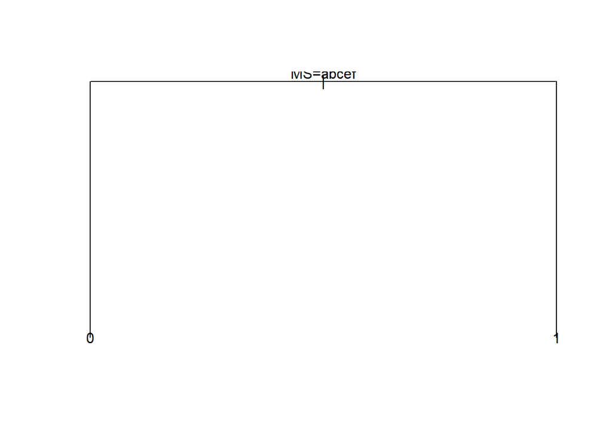

```r
plot(tree_model)
text(tree_model, use.n = TRUE)
```

Question 5: The decision tree model revealed marital status as the most important predictor of loneliness.